# Segmented signal vs whole signal

Gely Ancelin

08 mai, 2026, 12:17

The scientific context and the protocol are described in the readme file of the GitHub repository. The SPARC and NNP for the whole signal and segmented signal were computed in the Python project, and the results are presented in the Excel file “results_all.xlsx”.

# 1 Rstudio project

The aim of this code is to load the SPARC and NNP for the whole signal and segmented signal computed in the Python_project and look for a relationship.

## 1.1 Data organisation

### 1.1.2 File structure

The data are organized in an Excel file with the following columns:

# 2 Notebook organisation

In this notebook, we will perform the following steps :

# 3 Import libraries

```r
# import libraries to read excel and compute a plot
library(readxl)
library(ggplot2)
library(ggpubr)
library(dplyr)
library(stringr)
```

# 4 Load and visualise the data computed in the Python project

```r
# From data, import "results_repetition.xlsx"
data_subject <- read_excel("data/results_all.xlsx")
data_subject
```

| Signal name | SPARC | NNP | mean_SPARC_flexion | mean_NNP_flexion |
| --- | --- | --- | --- | --- |
| FlexionDos_001_av | -6.874907 | 1.670103 | -4.159162 | 1.8049464 |
| FlexionDos_002_av | -6.735183 | 3.946588 | -5.349642 | 3.4523434 |
| FlexionDos_003_av | -11.533392 | 3.625192 | -5.434564 | 4.4457368 |
| FlexionDos_004_av | -8.011311 | 1.224490 | -2.997148 | 1.1090865 |
| FlexionDos_005_av | -12.947031 | 5.095796 | -15.475841 | 5.8194583 |
| FlexionDos_006_av | -10.508508 | 2.743022 | -3.215461 | 2.5590365 |
| FlexionDos_007_av | -7.602682 | 1.015572 | -3.276752 | 0.9618833 |
| FlexionDos_008_av | -9.216218 | 3.790782 | -6.385948 | 3.9247799 |
| FlexionDos_009_av | -8.477055 | 1.893048 | -2.691233 | 2.4565432 |
| FlexionDos_010_av | -9.464665 | 4.101877 | -6.167191 | 4.3601598 |

# 5 Visualisation - Segmented signal vs whole signal

## 5.1 plot NNP as a function of NNP_flexion

This plot shows the relationship between NNP_flexion and NNP.

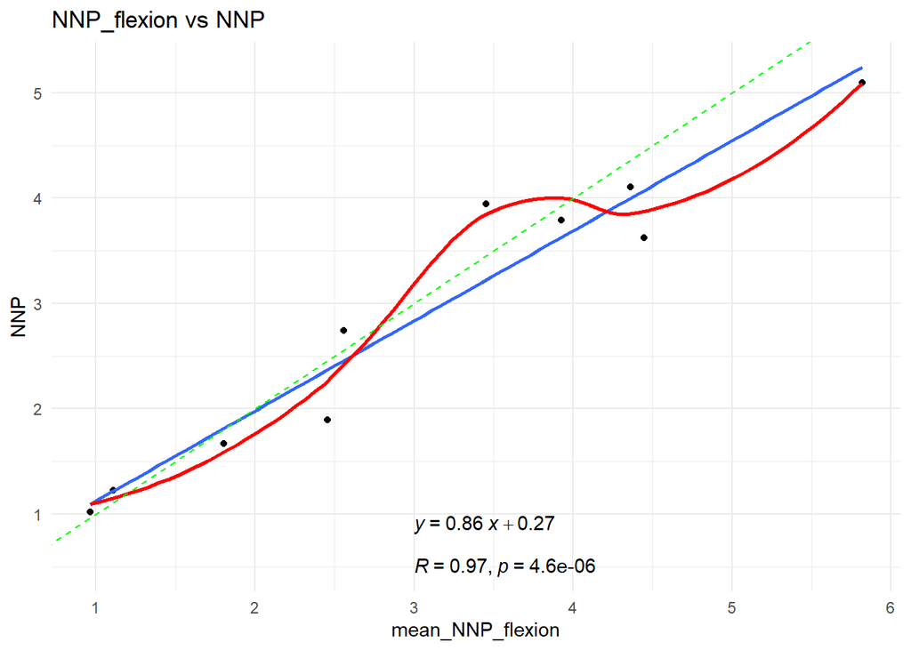

```r
# Plot NNP_flexion as a function of NNP
ggplot(data_subject, aes(x = mean_NNP_flexion, y = NNP)) +
  geom_point() +
  geom_smooth(method = "lm", se = FALSE) +
  geom_smooth(method = "loess", se = FALSE, color = "red") +
  geom_abline(slope = 1, intercept = 0, color = "green", linetype = "dashed") +
  # add the equation and the R-squared value to the plot
  stat_regline_equation(label.x = 3, label.y = 0.9) +
  stat_cor(method = "pearson", label.x = 3, label.y = 0.5) +
  labs(title = "NNP_flexion vs NNP",
       x = "mean_NNP_flexion",
       y = "NNP") +
  theme_minimal()
```

**Observation** : There is a positive correlation between NNP_flexion and NNP. Le loess fit (red line) and the linear fit (blue line) are quite similar, indicating that the relationship between NNP_flexion and NNP is approximately linear.

**Interpretation** This suggests that the whole signal and the segmented signal provide similar information about movement smoothness when using the NNP metric.

## 5.2 plot SPARC_flexion as a function of SPARC

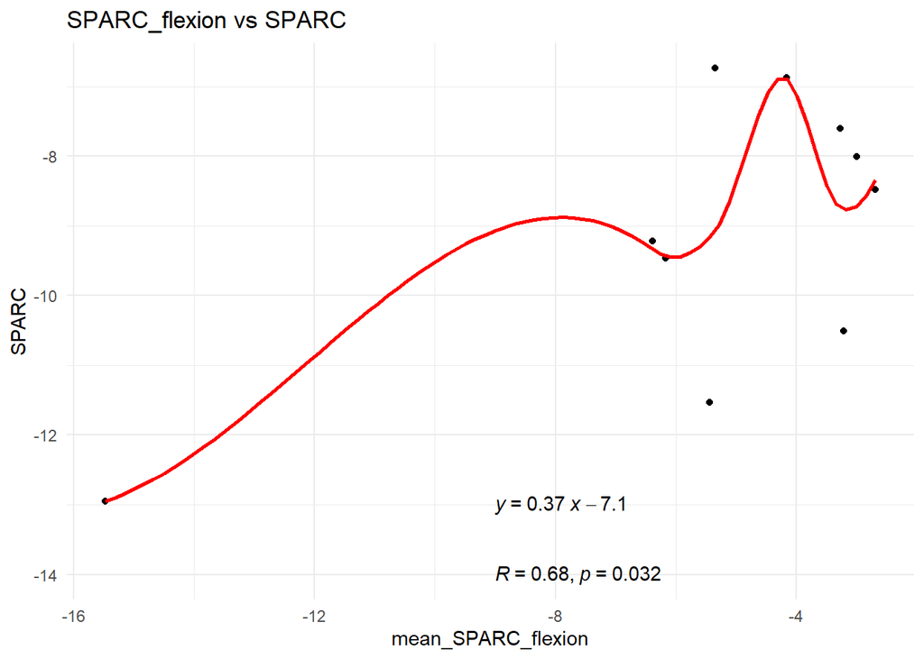

```r
# Plot SPARC_flexion as a function of SPARC
ggplot(data_subject, aes(x = mean_SPARC_flexion, y = SPARC)) +
  geom_point() +
  #geom_smooth(method = "lm", se = FALSE) +
  geom_smooth(method = "loess", se = FALSE, color = "red") +
  #geom_abline(slope = 1, intercept = 0, color = "green", linetype = "dashed") +
  stat_regline_equation(label.x = -9, label.y = -13) +
  stat_cor(method = "pearson", label.x = -9, label.y = - 14) +
  labs(title = "SPARC_flexion vs SPARC",
       x = "mean_SPARC_flexion",
       y = "SPARC") +
  theme_minimal()
```

**Observation** : No clear linear relationship between SPARC_flexion and SPARC. The loess fit (red line) shows a non-linear pattern.

**Results** : The slope value (0.37) indicates that for every unit increase in SPARC_flexion, there is an expected increase of 0.37 units in SPARC. The intercept value (-7.1) suggests that when SPARC_flexion is zero, SPARC is expected to be -7.1.

**Interpretation** : This suggests that the whole signal and the segmented signal provide different information about movement smoothness when using the SPARC metric.

This difference might be due to the fact that SPARC is more sensitive to movement duration and structure than NNP, which can lead to different values for the whole signal and the segmented signal.

# 6 Bland-Altman test

Correlation quantifies the degree to which two variables are linearly related, but it does not provide information about the agreement between the two methods. The bland-Altman test is a method to evaluate the agreement between two methods of measurement (7).

It consists in plotting the difference between the two methods against the mean of the two methods, and calculating the bias (mean difference) and the limits of agreement (bias ± 1.96 * standard deviation of the differences).

The difference has to be normally distributed, that’s the reason whya shapiro wilk test is performed (7).

$$difference = whole - segmented$$
Result of the Bland-Altman test will be presented in a table with the following columns :

- bias : mean difference between the whole signal and the segmented signal. This value indicates if there is a systematic difference between the two methods. A bias close to zero indicates good agreement between the two methods, while a bias different from zero indicates a systematic difference.

$$bias = mean(difference)$$
- Upper : upper limit of agreement (bias + 1.96 * sd). This value indicates the upper bound of the range in which most of the differences between the two methods are expected to lie. If the upper limit is close to zero, it suggests that there is good agreement between the two methods for high values.

$$\text{upper limit of agreement} = bias +
1.96 * sd$$
- lower : lower limit of agreement (bias - 1.96 * sd). This value indicates the lower bound of the range in which most of the differences between the two methods are expected to lie. If the lower limit is close to zero, it suggests that there is good agreement between the two methods for low values.

$$\text{lower limit of agreement} = bias -
1.96 * sd$$

- perc_bias : percentage bias (bias / mean of the two methods) * 100. This value indicates the bias as a percentage of the mean of the two methods. A smaller percentage bias indicates better agreement between the two methods.

$$\text{percentage bias} = \left(
\frac{bias}{\text{mean of the two methods}} \right) * 100$$

The result is a graph in which the x-axis represents the mean of the two methods and the y-axis represents the difference between the two methods. The bias is represented by a horizontal line, and the limits of agreement are represented by two dashed lines. 95% of the points should lie within the limits of agreement if the two methods are in good agreement (7)

The interpretation of this graph relies on the line of equality that should be within the limits of agreement, and on the limit of acceptable difference that should be defined a priori based on relevant criteria. (7)

## 6.1 Bland-Altman - NNP

```r
# Compute the Bland-Altman test

data_subject$mean_NNP <- (data_subject$NNP + data_subject$mean_NNP_flexion) / 2
data_subject$diff_NNP <- data_subject$NNP - data_subject$mean_NNP_flexion

# Shapiro wilk test to test the normal distribution of the differences
shapiro.test(data_subject$diff_NNP)
```

```
##
##  Shapiro-Wilk normality test
##
## data:  data_subject$diff_NNP
## W = 0.9607, p-value = 0.7938
```

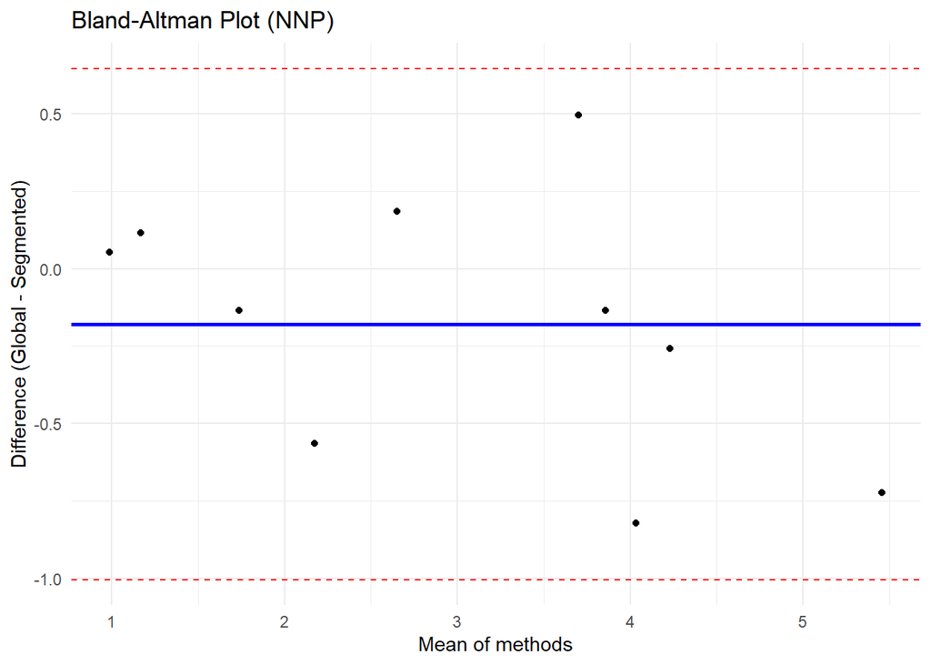

```r
bias_NNP <- mean(data_subject$diff_NNP, na.rm = TRUE)
sd_NNP <- sd(data_subject$diff_NNP, na.rm = TRUE)

upper_NNP <- bias_NNP + 1.96 * sd_NNP
lower_NNP <- bias_NNP - 1.96 * sd_NNP

# Plot
ggplot(data_subject, aes(x = mean_NNP, y = diff_NNP)) +
  geom_point(linewidth = 3) +
  geom_hline(yintercept = bias_NNP, color = "blue", size = 1) +
  geom_hline(yintercept = upper_NNP, linetype = "dashed", color = "red") +
  geom_hline(yintercept = lower_NNP, linetype = "dashed", color = "red") +
  labs(title = "Bland-Altman Plot (NNP)",
       x = "Mean of methods",
       y = "Difference (Global - Segmented)") +
  theme_minimal()
```

## 6.2 Bland-Altman test - SPARC

```r
# Compute the Bland-Altman test
data_subject$mean_SPARC <- (data_subject$SPARC + data_subject$mean_SPARC_flexion) / 2
data_subject$diff_SPARC <- data_subject$SPARC - data_subject$mean_SPARC_flexion

# Shapiro wilk test to test the normal distribution of the differences
shapiro.test(data_subject$diff_SPARC)
```

```
##
##  Shapiro-Wilk normality test
##
## data:  data_subject$diff_SPARC
## W = 0.93469, p-value = 0.4956
```

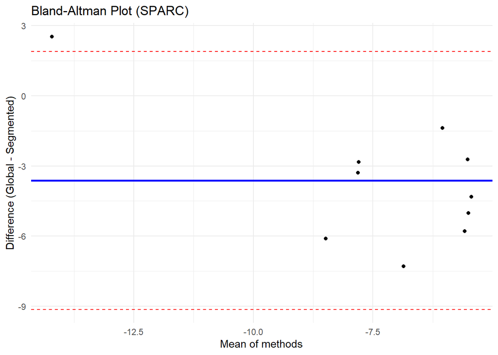

```r
bias_SPARC <- mean(data_subject$diff_SPARC, na.rm = TRUE)
sd_SPARC <- sd(data_subject$diff_SPARC, na.rm = TRUE)

upper_SPARC <- bias_SPARC + 1.96 * sd_SPARC
lower_SPARC <- bias_SPARC - 1.96 * sd_SPARC

# Plot
ggplot(data_subject, aes(x = mean_SPARC, y = diff_SPARC)) +
  geom_point(linewidth = 3) +
  geom_hline(yintercept = bias_SPARC, color = "blue", size = 1) +
  geom_hline(yintercept = upper_SPARC, linetype = "dashed", color = "red") +
  geom_hline(yintercept = lower_SPARC, linetype = "dashed", color = "red") +
  labs(title = "Bland-Altman Plot (SPARC)",
       x = "Mean of methods",
       y = "Difference (Global - Segmented)") +
  theme_minimal()
```

```r
# % bias NNP
mean_NNP_all <- mean(c(data_subject$NNP, data_subject$mean_NNP_flexion), na.rm = TRUE)
perc_bias_NNP <- (bias_NNP / mean_NNP_all) * 100

# % bias SPARC
mean_SPARC_all <- mean(c(data_subject$SPARC, data_subject$mean_SPARC_flexion), na.rm = TRUE)
perc_bias_SPARC <- (bias_SPARC / mean_SPARC_all) * 100

ba_table <- data.frame(
  methode = c("NNP", "SPARC"),
  bias = c(bias_NNP, bias_SPARC),
  sd = c(sd_NNP, sd_SPARC),
  lower = c(lower_NNP, lower_SPARC),
  upper = c(upper_NNP, upper_SPARC),
  perc_bias = c(perc_bias_NNP, perc_bias_SPARC)
  )

ba_table
```

| methode | bias | sd | lower | upper | perc_bias |
| --- | --- | --- | --- | --- | --- |
| NNP | -0.1787504 | 0.4206036 | -1.003134 | 0.6456326 | -5.958304 |
| SPARC | -3.6218010 | 2.8109842 | -9.131330 | 1.8877280 | 49.436319 |

The best way to interpret these results would be to define a priori the limit of maximal acceptable difference, based on relevant criteria. Unfortunately, as our method is rarely used, mostly in a flexion movement, there is no consensus about this limit. However, we can look at the percentage bias to have an idea of the agreement between the two methods.

This result is consistent with the correlation results and support our hypothesis.

# 7 Discussion :

The weak correlation between SPARC_flexion and SPARC, as well as the high percentage bias, suggest that the whole signal and the segmented signal give different values. It confirms the fact that SPARC should not be computed on the whole signal (4).

The bias for NNP is moderate (-5,95%). It might be due to the fact that the whole signal includes resting periods that may decrease the number of peaks in the whole signal compared to the segmented signal, which only includes the flexion movement. Moreover, the whole signal contains concentric and eccentric movement which lie on different motor control strategies and can have different NNP values. It would be interesting to look at the NNP for the extension movement to see if it is different from the NNP for the flexion movement, and if it can explain the bias between the whole signal and the segmented signal. Finally, it would be interesting to perform a sensitivity analysis to see if prominence chosen in the NNP calculation can influence the bias between the whole signal and the segmented signal.

However, the bias is relatively low and might be acceptable, depending on the context and the criteria for maxiaml acceptable difference.

# 8 Perspective :

Future works should focus on determine a limit of maximal acceptable difference for both NNP and SPARC. This would allow us to better interpret the results of the Bland-Altman test and to determine if the agreement between the whole signal and the segmented signal is acceptable for clinical use.

# 9 Conclusion

the NNP metric shows a strong correlation between the whole signal and the segmented signal, with a low percentage bias (-5,95%).The SPARC metric shows a weaker correlation between the whole signal and the segmented signal, with a higher percentage bias (49,4%).

Concerning our study on **the evolution of movement smoothness in trunck flexion before and after a rehabilitation program in individuals with low back pain** : We confirm that the SPARC metric should not be computed on a whole signal. Some caution should be taken when using the whole signal as a proxy for the segmented signal for NNP metric, as there is a moderate bias between the two methods. However, the strong correlation and the relatively low percentage bias suggest that the whole signal might be an acceptable proxy for the segmented signal when using the NNP metric, depending on the context and the criteria for maximal acceptable difference.

# 10 References :

1. Hartvigsen J, Hancock MJ, Kongsted A, Louw Q, Ferreira ML, Genevay S, et al. What low back pain is and why we need to pay attention. Lancet Lond Engl. 9 juin 2018;391(10137):2356‑67
2. Errabity A, Calmels P, Han WS, Bonnaire R, Pannetier R, Convert R, et al. The effect of low back pain on spine kinematics: A systematic review and meta-analysis. Clin Biomech. août 2023;108:106070
3. Balasubramanian S, Melendez-Calderon A, Roby-Brami A, Burdet E. On the analysis of movement smoothness. J Neuroengineering Rehabil. 9 déc 2015;12:112
4. Balasubramanian S, Melendez-Calderon A, Roby-Brami A, Burdet E. On the analysis of movement smoothness. J Neuroeng Rehabil. 9 déc 2015;12:112. doi:10.1186/s12984-015-0090-9 PubMed PMID: 26651329; PubMed Central PMCID: PMC4674971.
5. Melendez-Calderon A, Shirota C, Balasubramanian S. Estimating Movement Smoothness From Inertial Measurement Units. Front Bioeng Biotechnol. 14 janv 2021;8:558771. doi:10.3389/fbioe.2020.558771
6. https://github.com/ancelingely/Projet_R_Python_M2_REHAB.git
7. Giavarina D. Understanding Bland Altman analysis. Biochem Med. 2015;25(2):141‑51. doi:10.11613/BM.2015.015